# Intro: Creating an NFL offensive playcall predictor

Running an NFL defense can be a stressful and time-consuming job. Even after all the preparation throughout the week, a defense could go out and get curb stomped for seemingly no reason. This is due to the fact that even if a team prepares all week, and watches all the film, they still don't know what play is going to be called on down by down basis. I want to attempt to solve that by creating a play call predictor that takes is able to correctly predict if a pass or run is being called.

# Part 1 & 2: Data Collection and Parsing/Data management and representaion

```python
from sklearn.metrics import accuracy_score
import matplotlib.pyplot as plt
from sklearn import ensemble
import pandas as pd
import numpy as np

df = pd.read_csv('/content/NFL Play by Play 2009-2018 (v5).csv')

#creating cols in the dataset
df = df[['game_date', 'posteam','yardline_100','quarter_seconds_remaining','half_seconds_remaining','game_seconds_remaining','qtr','down','goal_to_go','ydstogo','play_type','score_differential','shotgun','no_huddle']]
#dropping rows that have bad data
df = df.dropna()

df.head(10)
```

|  | game_date | posteam | yardline_100 | quarter_seconds_remaining | half_seconds_remaining | game_seconds_remaining | qtr | down | goal_to_go | ydstogo | play_type | score_differential | shotgun | no_huddle |
| --- | --- | --- | --- | --- | --- | --- | --- | --- | --- | --- | --- | --- | --- | --- |
| 1 | 2009-09-10 | PIT | 58.0 | 893.0 | 1793.0 | 3593.0 | 1 | 1.0 | 0.0 | 10 | pass | 0.0 | 0 | 0 |
| 2 | 2009-09-10 | PIT | 53.0 | 856.0 | 1756.0 | 3556.0 | 1 | 2.0 | 0.0 | 5 | run | 0.0 | 0 | 0 |
| 3 | 2009-09-10 | PIT | 56.0 | 815.0 | 1715.0 | 3515.0 | 1 | 3.0 | 0.0 | 8 | pass | 0.0 | 1 | 0 |
| 4 | 2009-09-10 | PIT | 56.0 | 807.0 | 1707.0 | 3507.0 | 1 | 4.0 | 0.0 | 8 | punt | 0.0 | 0 | 0 |
| 5 | 2009-09-10 | TEN | 98.0 | 796.0 | 1696.0 | 3496.0 | 1 | 1.0 | 0.0 | 10 | run | 0.0 | 0 | 0 |
| 6 | 2009-09-10 | TEN | 98.0 | 760.0 | 1660.0 | 3460.0 | 1 | 2.0 | 0.0 | 10 | pass | 0.0 | 0 | 0 |
| 7 | 2009-09-10 | TEN | 94.0 | 731.0 | 1631.0 | 3431.0 | 1 | 3.0 | 0.0 | 6 | run | 0.0 | 1 | 0 |
| 8 | 2009-09-10 | TEN | 96.0 | 694.0 | 1594.0 | 3394.0 | 1 | 4.0 | 0.0 | 8 | punt | 0.0 | 0 | 0 |
| 9 | 2009-09-10 | PIT | 43.0 | 684.0 | 1584.0 | 3384.0 | 1 | 1.0 | 0.0 | 10 | pass | 0.0 | 0 | 0 |
| 10 | 2009-09-10 | PIT | 40.0 | 648.0 | 1548.0 | 3348.0 | 1 | 2.0 | 0.0 | 7 | pass | 0.0 | 0 | 0 |

# Part 3: Exploratory Data Analysis

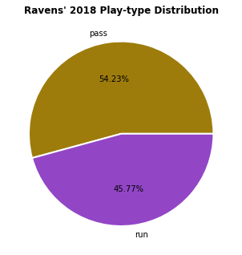

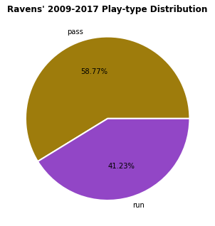

```python
#Creating training and test datasets for later
training_df = df[(~df.game_date.str.contains('2018')) & (df.posteam == 'BAL') & (df.down.isin(range(1,5))) & ((df.play_type == 'run') | (df.play_type == 'pass'))]

testing_df = df[(df.game_date.str.contains('2018')) & (df.posteam == 'BAL') & (df.down.isin(range(1,5))) & ((df.play_type == 'run') | (df.play_type == 'pass'))]

#Analysis on the Testing dataset
rel_freq = testing_df['play_type'].value_counts()

colors = {'#9246C6', '#9E7C0C'}
#Creating a pie chart for the relative frequency of pass or run in the test set
plt.pie(rel_freq, labels = ('pass', 'run'), autopct='%.2f%%', wedgeprops = { 'linewidth' : 2, 'edgecolor' : 'white' }, colors = colors)
plt.title("Ravens' 2018 Play-type Distribution", fontname="Times New Roman", fontweight="bold")
plt.subplots_adjust(left=0, bottom=0, right=1, top=1, wspace=0, hspace=0)
plt.show()

#Analysis on the Training Dataset
rel_freq = training_df['play_type'].value_counts()
#Creating a pie chart for the relative frequency of pass or run in the training set
plt.pie(rel_freq, labels = ('pass', 'run'), autopct='%.2f%%', wedgeprops = { 'linewidth' : 2, 'edgecolor' : 'white' }, colors = colors)
plt.title("Ravens' 2009-2017 Play-type Distribution", fontname="Times New Roman", fontweight="bold")
plt.subplots_adjust(left=0, bottom=0, right=1, top=1, wspace=0, hspace=0)
plt.show()
```

The test set consists of the same type of plays except for all the plays in the test set are IN the 2018 season. So we're training the predictor with all pass/run plays outside of 2018 and testing it to see if it can predict the 2018 play calls.

Secondly, I graphed the play call breakdown between the test set and the training set. This allows us to see how pass-heavy vs run-heavy the ravens were as a whole during the 2009-2017 time period as well as the 2018 season. This could be beneficial as it could show that while the Ravens were slightly pass-heavy, they ran the ball a lot leading to a predictor that favors the run a bit more than if we trained it with another team.

As we can see the Ravens pass around 56% of the time and while this doesn't shock me as the league has more of a passing trend, it is a tiny bit surprising as the Ravens have had one of the more dominant run games in the league. Now, there are both advantages and disadvantages to relying heavily on the passing game. One advantage is that the passing game can be a quick and efficient way to move the ball down the field and score points. It can also be difficult for defenses to defend against, as there are many different routes and options that receivers can run and many different ways that a quarterback can deliver the ball. However, there are also risks associated with relying too heavily on the passing game. If a team's passing attack is not successful, it can lead to a lack of offensive production and put pressure on the defense to keep the team in the game. Additionally, a heavy reliance on the passing game can make a team one-dimensional and easier for defenses to predict and stop. While the Ravens may not suffer from the pitfalls of a full passing offense other teams will

Also, using the graph as a baseline it can be said that a predictor that predicts if a pass play was called would be accurate 54.23% of the time if trained on the training data.

# Part 4: Actually Making the Predictor

```python
#creating a features list for the training set
train_feat = training_df[['yardline_100','quarter_seconds_remaining',
                        'half_seconds_remaining','game_seconds_remaining',
                        'qtr','down','goal_to_go','ydstogo',
                        'score_differential','shotgun','no_huddle']]

train_label = training_df['play_type']

#creating a features list for the test set
test_feat = testing_df[['yardline_100','quarter_seconds_remaining',
                        'half_seconds_remaining','game_seconds_remaining',
                        'qtr','down','goal_to_go','ydstogo',
                        'score_differential','shotgun','no_huddle']]

test_label = testing_df['play_type']

#Using a gradient boosting classifier and fitting it with the training data
gbr = ensemble.GradientBoostingClassifier(n_estimators = 100, learning_rate = 0.02)

gbr.fit(train_feat, train_label)
```

```
GradientBoostingClassifier(learning_rate=0.02)
```

What is going on here: Here I am actually creating the predictor using the training set I created. I used a gradient-boosting classifier as my machine-learning algorithm for this project. One of the main benefits of gradient boosting is that it can produce highly accurate predictive models, especially in situations where the relationships between the features and the target variable are complex. It is also resistant to overfitting, as the weak models are trained sequentially and the ensemble is built by adding models that correct the errors made by previous models. This means that the model is less prone to overfitting and can generalize well to unseen data. If you want to look into GBC check out these links

1. https://scikit-learn.org/stable/modules/generated/sklearn.ensemble.GradientBoostingClassifier.html#sklearn.ensemble.GradientBoostingClassifier
2. https://medium.com/mlreview/gradient-boosting-from-scratch-1e317ae4587d

Firstly, I am organizing my feature lists to be used. Then I am creating and feed the GBC the training features, thus training the algo to make predictions based on said training data.

Now the predictor is trained but isn't being used so let's put it to work.

```python
prediction = gbr.predict(test_feat)

accuracy = accuracy_score(test_label, prediction)

print("Accuracy: "+"{:.2%}".format(accuracy))
```

```
Accuracy: 61.47%
```

What this means: Based on the accuracy of our now-trained predictor it seems like a decent increase over the baseline we had set(54.23%). While this accuracy seems a tad lower than one would want, it is still a great improvement as being able to predict an offensive play call over 60% of the time would mean wonders for a defense.

I also wanted to see what features were most influential in the predictor so I created a graph of that below:

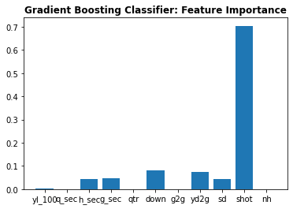

```python
features = ['yl_100', 'q_sec', 'h_sec', 'g_sec', 'qtr', 'down' ,'g2g', 'yd2g', 'sd', 'shot', 'nh']

feature_importance = gbr.feature_importances_.tolist()

plt.bar(features,feature_importance)
plt.title("Gradient Boosting Classifier: Feature Importance",fontname="Times New Roman", fontweight="bold")
```

As can be seen, being in shotgun formation is clearly the most important feature in the data frame. With shotgun formation being so high it can be assumed that the Ravens passed a ton while in that formation, lets take a look for ourselves.

```
<function matplotlib.pyplot.show(*args, **kw)>
```

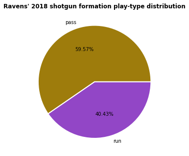

```python
shotgun_df = df[(df.game_date.str.contains('2018')) & (df.posteam == 'BAL') & (df.down.isin(range(1,5))) & ((df.play_type == 'run') | (df.play_type == 'pass')) & (df.shotgun == 1)]

relative_frequency = shotgun_df['play_type'].value_counts()

colors = {'#9246C6', '#9E7C0C'}
#Creating a pie chart that represents the relative frequency of a pass or run while in shotgun formation
plt.pie(relative_frequency, labels = ('pass', 'run'), autopct='%.2f%%', wedgeprops = { 'linewidth' : 2, 'edgecolor' : 'white' }, colors = colors)
plt.title("Ravens' 2018 shotgun formation play-type distribution",fontname="Times New Roman", fontweight="bold")
plt.subplots_adjust(left=0, bottom=0, right=1, top=1, wspace=0, hspace = 0)
plt.show
```

Wow! I thought passing would have been a much bigger percentage of the play calls, thus causing the feature to be so heavily weighted, however, it was still almost 60% which is a lot in NFL terms.

Getting curious I would also like to see how downs factored into the play call so we will do that here:

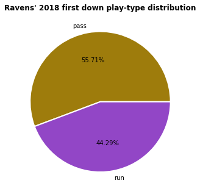

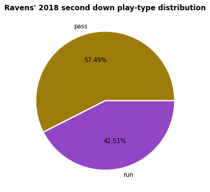

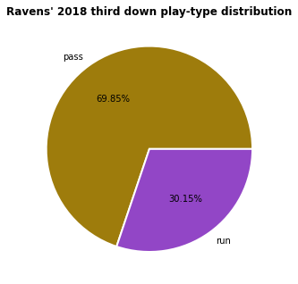

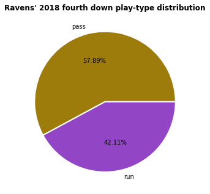

```python
#Passing on first down
down_1_df = df[(df.game_date.str.contains('2018')) & (df.posteam == 'BAL') & (df.down.isin(range(1,5))) & ((df.play_type == 'run') | (df.play_type == 'pass')) & (df.down == 1)]

relative_frequency = down_1_df['play_type'].value_counts()

colors = {'#9246C6', '#9E7C0C'}

plt.pie(relative_frequency, labels = ('pass', 'run'), autopct='%.2f%%', wedgeprops = { 'linewidth' : 2, 'edgecolor' : 'white' }, colors = colors)
plt.title("Ravens' 2018 first down play-type distribution",fontname="Times New Roman", fontweight="bold")
plt.subplots_adjust(left=0, bottom=0, right=1, top=1, wspace=0, hspace = 0)
plt.show()

#Passing on Second down
down_2_df = df[(df.game_date.str.contains('2018')) & (df.posteam == 'BAL') & (df.down.isin(range(1,5))) & ((df.play_type == 'run') | (df.play_type == 'pass')) & (df.down == 2)]

relative_frequency = down_2_df['play_type'].value_counts()

colors = {'#9246C6', '#9E7C0C'}

plt.pie(relative_frequency, labels = ('pass', 'run'), autopct='%.2f%%', wedgeprops = { 'linewidth' : 2, 'edgecolor' : 'white' }, colors = colors)
plt.title("Ravens' 2018 second down play-type distribution",fontname="Times New Roman", fontweight="bold")
plt.subplots_adjust(left=0, bottom=0, right=1, top=1, wspace=0, hspace = 0)
plt.show()

#Passing on third down
down_3_df = df[(df.game_date.str.contains('2018')) & (df.posteam == 'BAL') & (df.down.isin(range(1,5))) & ((df.play_type == 'run') | (df.play_type == 'pass')) & (df.down == 3)]

relative_frequency = down_3_df['play_type'].value_counts()

colors = {'#9246C6', '#9E7C0C'}

plt.pie(relative_frequency, labels = ('pass', 'run'), autopct='%.2f%%', wedgeprops = { 'linewidth' : 2, 'edgecolor' : 'white' }, colors = colors)
plt.title("Ravens' 2018 third down play-type distribution",fontname="Times New Roman", fontweight="bold")
plt.subplots_adjust(left=0, bottom=0, right=1, top=1, wspace=0, hspace = 0)
plt.show()

#Passing on fourth down
down_4_df = df[(df.game_date.str.contains('2018')) & (df.posteam == 'BAL') & (df.down.isin(range(1,5))) & ((df.play_type == 'run') | (df.play_type == 'pass')) & (df.down == 4)]

relative_frequency = down_4_df['play_type'].value_counts()

colors = {'#9246C6', '#9E7C0C'}

plt.pie(relative_frequency, labels = ('pass', 'run'), autopct='%.2f%%', wedgeprops = { 'linewidth' : 2, 'edgecolor' : 'white' }, colors = colors)
plt.title("Ravens' 2018 fourth down play-type distribution",fontname="Times New Roman", fontweight="bold")
plt.subplots_adjust(left=0, bottom=0, right=1, top=1, wspace=0, hspace = 0)
plt.show()
```

As we can see in the graphs above, there was only really a significant boost in passing calls made on third down. This makes a decent amount of sense in the NFL world as on third down a team is most likely to have to travel the farthest to gain a first down. When it comes to our predictor, however, this makes it make sense that while down has some influence it is nowhere near shotgun formation as only 1/4 of the down warrants a heavier weighting.

# Part 5: Testing the Predictor on other teams

Now that I have created an offensive predictor for solely the Ravens I'd like to see how the predictor would perform on other teams. All teams have different coaches and different schemes, but there are a decent amount of commonalities between teams and overall offensive trends in the NFL. Now the Ravens are a more run-heavy team so which caused a dip in performance I expect the algo to predict pass-heavy teams better.

```python
df['posteam'].replace('STL','LA',inplace=True)
df['posteam'].replace('SD','LAC',inplace=True)
df['posteam'].replace('JAC','JAX',inplace=True)

len(df.posteam.unique())
```

```
32
```

First, we must account for teams that have moved in the time period of the data to make it so that there are 32 total teams. That was performed above.

```python
res = pd.DataFrame(columns =['accuracy'])

for team in df.posteam.unique():

    testing_df = df[(df.game_date.str.contains('2018')) & (df.posteam == team) & (df.down.isin(range(1,5))) & ((df.play_type == 'run') | (df.play_type == 'pass'))]

    test_feat = testing_df[['yardline_100','quarter_seconds_remaining','half_seconds_remaining',
                                   'game_seconds_remaining','qtr','down','goal_to_go','ydstogo',
                                   'score_differential','shotgun','no_huddle']]
    test_label = testing_df['play_type']

    prediction = gbr.predict(test_feat)
    accuracy = accuracy_score(test_label, prediction)

    res.loc[team] = [accuracy]
```

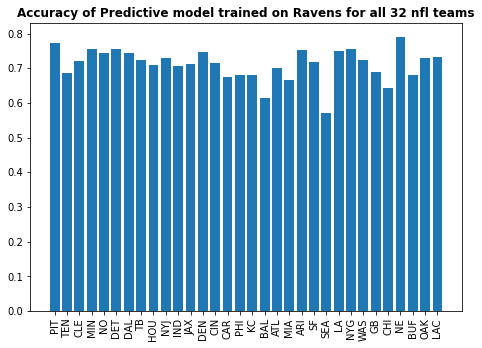

```python
plt.bar(res.index,res.accuracy)
plt.xticks(rotation=90)
plt.title("Accuracy of Predictive model trained on Ravens for all 32 nfl teams", fontname="Times New Roman", fontweight="bold")
plt.subplots_adjust(left=0, bottom=0, right=1, top=1, wspace=0, hspace=0)
plt.show()
```

```python
#Used to output the avg accuracy of the function
res['accuracy'].mean()
```

```
0.7120228652202645
```

# Conclusion

Completing this project allowed me to enhance my skills in a multitude of ways. I was able to increase my proficiency in creating graphs, formatting large data sets, and training computer algorithms. While this project doesn't eliminate the need for practice or a defensive coordinator, it could help influence some decisions made in crunch time. And it actually already does as data science is used throughout almost every major sport today. I hope that this tutorial was helpful in some way, and if not I hope it was at least interesting. Thanks for following along.

-Wyatt Scott

```python
%%shell
jupyter nbconvert --to html /content/Final_320_Offense_Predict.ipynb
```

```
[NbConvertApp] Converting notebook /content/Final_320_Offense_Predict.ipynb to html
[NbConvertApp] Writing 517286 bytes to /content/Final_320_Offense_Predict.html
```